# Analysis of the Chipotle Dataset

The dataset can be found here: https://github.com/TheUpshot/chipotle/blob/master/orders.tsv

Context information for which purposes the dataset was collected is given in this article: https://www.nytimes.com/interactive/2015/02/17/upshot/what-do-people-actually-order-at-chipotle.html

**Short Description**: The dataset was originally collected around 2015 to get insights into typcial orders at the fast-food chain "Chipotle". The data does not directly come from Chipotle restaurants, but from the US food delivery service *Grubhub*. This is important to know, because this fact may influence orders (e.g. less softdrinks).

The dataset consists of 1834 orders, that are described by the columns **order_id, quantity, item_name, choice_description and item_price**. The same **order_id** appears multiple times to indicate that an order consists of multiple items.

The analysis consists of **four main tasks**:

- Data Cleaning and Extension
- Descriptive Statistics
- Correlations between attributes
- Clustering

## Data Cleaning and Extension

```python
import pandas as pd
from ast import literal_eval
import numpy as np
```

```python
#read data
df = pd.read_csv("./data/orders.tsv", sep='\t', header=0)
df.columns
```

```
Index(['order_id', 'quantity', 'item_name', 'choice_description',
       'item_price'],
      dtype='object')
```

```python
df.head()
```

|  | order_id | quantity | item_name | choice_description | item_price |
| --- | --- | --- | --- | --- | --- |
| 0 | 1 | 1 | Chips and Fresh Tomato Salsa | NaN | $2.39 |
| 1 | 1 | 1 | Izze | [Clementine] | $3.39 |
| 2 | 1 | 1 | Nantucket Nectar | [Apple] | $3.39 |
| 3 | 1 | 1 | Chips and Tomatillo-Green Chili Salsa | NaN | $2.39 |
| 4 | 2 | 2 | Chicken Bowl | [Tomatillo-Red Chili Salsa (Hot), [Black Beans... | $16.98 |

First lets clean the price from the dollar sign and aggergate a sum for each order.

```python
df['item_price_clean'] = df['item_price'].apply(lambda x: float(x.strip()[1:]))
df['order_total'] = df.groupby('order_id')['item_price_clean'].transform(np.sum)
df.head(3)
```

|  | order_id | quantity | item_name | choice_description | item_price | item_price_clean | order_total |
| --- | --- | --- | --- | --- | --- | --- | --- |
| 0 | 1 | 1 | Chips and Fresh Tomato Salsa | NaN | $2.39 | 2.39 | 11.56 |
| 1 | 1 | 1 | Izze | [Clementine] | $3.39 | 3.39 | 11.56 |
| 2 | 1 | 1 | Nantucket Nectar | [Apple] | $3.39 | 3.39 | 11.56 |

When we examined the data beforehand we saw that the choice description column needs some flattening.

Further we found out that pandas reads this as strings, thus some further string parsing is necessary.

First we need to make the Strings a List of Strings

```python
#horrendous testing
x = '[[Fresh Tomato Salsa (Mild), Roasted Chili Corn Salsa (Medium)], [Black Beans, Rice, Fajita Veggies, Cheese, Sour Cream, Lettuce]]'
x = '\'' + x.replace('[','').replace(']','').replace(',','\',\'') + '\''
print(literal_eval(x))
```

```
('Fresh Tomato Salsa (Mild)', ' Roasted Chili Corn Salsa (Medium)', ' Black Beans', ' Rice', ' Fajita Veggies', ' Cheese', ' Sour Cream', ' Lettuce')
```

```python
#correct lists of the choice_description
#first replace Nan values with a NaN String so the literal_eval method can handle it.
df['choice_description'] = df['choice_description'].fillna('NaN')
#then replace all the brackets and insert quotes so the strings are parsed correctly
df['choice_description'] = df.choice_description.apply(
    lambda x: literal_eval(('\'' + x.replace('[','').replace(']','').replace(',','\',\'') + '\'').replace(' ','').replace('-','').replace('Braised','').strip())
)
df.head(6)
```

|  | order_id | quantity | item_name | choice_description | item_price | item_price_clean | order_total |
| --- | --- | --- | --- | --- | --- | --- | --- |
| 0 | 1 | 1 | Chips and Fresh Tomato Salsa | NaN | $2.39 | 2.39 | 11.56 |
| 1 | 1 | 1 | Izze | Clementine | $3.39 | 3.39 | 11.56 |
| 2 | 1 | 1 | Nantucket Nectar | Apple | $3.39 | 3.39 | 11.56 |
| 3 | 1 | 1 | Chips and Tomatillo-Green Chili Salsa | NaN | $2.39 | 2.39 | 11.56 |
| 4 | 2 | 2 | Chicken Bowl | (TomatilloRedChiliSalsa(Hot), BlackBeans, Rice... | $16.98 | 16.98 | 16.98 |
| 5 | 3 | 1 | Chicken Bowl | (FreshTomatoSalsa(Mild), Rice, Cheese, SourCre... | $10.98 | 10.98 | 12.67 |

Other thing we found out was that the option of "braised" is not really an option and like this every time. So we remove the "braised".

Also we could find out that there is categories of items:

- BurritoBowl
- Burrito
- Salad
- SaladBowl
- Crispy Taco
- Soft Taco
- Chips
- Drinks

We will add a item category for them.

Further we will add a meat category filled with the kind of meat or veggie or NaN if there is no option for it.

```python
#df['choice_description_clean'] = df['choice_description'].str.replace('-','').replace(' ','').apply(lambda s: s.strip())
df['item_name_clean'] = df['item_name'].str.replace('-','').str.replace(' ', '')
print(df.item_name_clean.unique().shape)
df.item_name_clean.unique()
```

```
(47,)
```

```
array(['ChipsandFreshTomatoSalsa', 'Izze', 'NantucketNectar',
       'ChipsandTomatilloGreenChiliSalsa', 'ChickenBowl', 'SideofChips',
       'SteakBurrito', 'SteakSoftTacos', 'ChipsandGuacamole',
       'ChickenCrispyTacos', 'ChickenSoftTacos', 'ChickenBurrito',
       'CannedSoda', 'BarbacoaBurrito', 'CarnitasBurrito', 'CarnitasBowl',
       'BottledWater', 'BarbacoaBowl', 'Chips', 'ChickenSaladBowl',
       'SteakBowl', 'BarbacoaSoftTacos', 'VeggieBurrito', 'VeggieBowl',
       'SteakCrispyTacos', 'ChipsandTomatilloRedChiliSalsa',
       'BarbacoaCrispyTacos', 'VeggieSaladBowl',
       'ChipsandRoastedChiliCornSalsa', 'CarnitasSoftTacos',
       'ChickenSalad', 'CannedSoftDrink', 'SteakSaladBowl',
       '6PackSoftDrink', 'Bowl', 'Burrito', 'CrispyTacos',
       'CarnitasCrispyTacos', 'SteakSalad',
       'ChipsandMildFreshTomatoSalsa', 'VeggieSoftTacos',
       'CarnitasSaladBowl', 'BarbacoaSaladBowl', 'Salad',
       'VeggieCrispyTacos', 'VeggieSalad', 'CarnitasSalad'], dtype=object)
```

```python
#cleaned in conversion process
print(df.choice_description.unique().shape)
df.choice_description.unique()
```

```
(1044,)
```

```
array(['NaN', 'Clementine', 'Apple', ...,
       ('RoastedChiliCornSalsa', 'PintoBeans', 'SourCream', 'Cheese', 'Lettuce', 'Guacamole'),
       ('TomatilloGreenChiliSalsa', 'Rice', 'BlackBeans'),
       ('TomatilloGreenChiliSalsa', 'Rice', 'FajitaVegetables', 'BlackBeans', 'Guacamole')],
      dtype=object)
```

```python
#returns the item class as string
def item_class(n):
    if 'Bowl' in n:
        if 'Salad' in n:
            return 'SaladBowl'
        elif 'Chicken' in n:
            return 'ChickenBowl'
        return 'BurritoBowl'
    if 'Crispy' in n:
        return 'CrispyTaco'
    if 'Taco' in n:
        return 'SoftTaco'
    if 'Burrito' in n:
        return 'Burrito'
    if 'Salad' in n:
        return 'Salad'
    if 'Chips' in n:
        return 'Chips'
    return 'Drink'

#returns the meat option if there is one
def meat_option(n):
    if 'Steak' in n:
        return 'Steak'
    if 'Chicken' in n:
        return 'Chicken'
    if 'Carnitas' in n:
        return 'Carnitas'
    if 'Barbacoa' in n:
        return 'Barbacoa'
    if 'Veggie' in n:
        return 'Veggie'
    return 'No meat'
```

```python
#add item_class
df['item_class'] = df.item_name_clean.apply(lambda n: item_class(n))
#add meat_option
df['meat_option'] = df.item_name_clean.apply(lambda n: meat_option(n))
```

```python
df.head(5)
```

|  | order_id | quantity | item_name | choice_description | item_price | item_price_clean | order_total | item_name_clean | item_class | meat_option |
| --- | --- | --- | --- | --- | --- | --- | --- | --- | --- | --- |
| 0 | 1 | 1 | Chips and Fresh Tomato Salsa | NaN | $2.39 | 2.39 | 11.56 | ChipsandFreshTomatoSalsa | Chips | No meat |
| 1 | 1 | 1 | Izze | Clementine | $3.39 | 3.39 | 11.56 | Izze | Drink | No meat |
| 2 | 1 | 1 | Nantucket Nectar | Apple | $3.39 | 3.39 | 11.56 | NantucketNectar | Drink | No meat |
| 3 | 1 | 1 | Chips and Tomatillo-Green Chili Salsa | NaN | $2.39 | 2.39 | 11.56 | ChipsandTomatilloGreenChiliSalsa | Chips | No meat |
| 4 | 2 | 2 | Chicken Bowl | (TomatilloRedChiliSalsa(Hot), BlackBeans, Rice... | $16.98 | 16.98 | 16.98 | ChickenBowl | ChickenBowl | Chicken |

Now lets create a column with one hot encoded choices:

- first we need to make everything a tuple, otherwise the later transforms are not going to work
- then we join them and one hot them for each element
- lastly we drop temp columns and add the new one

```python
#make every row a tuple
df['choice_description_onehot'] = df['choice_description'].apply(lambda x: x if type(x) is tuple else tuple([x,'']))
df['choice_description_onehot'].head(6)
```

```
0                                              (NaN, )
1                                       (Clementine, )
2                                            (Apple, )
3                                              (NaN, )
4    (TomatilloRedChiliSalsa(Hot), BlackBeans, Rice...
5    (FreshTomatoSalsa(Mild), Rice, Cheese, SourCre...
Name: choice_description_onehot, dtype: object
```

```python
#create dummies
dummy = df['choice_description_onehot'].str.join(sep='$').str.get_dummies(sep='$')
#add prefix
dummy.columns = ['choice_' + str(col) for col in dummy.columns]
dummy
```

|  | choice_AdoboMarinatedandGrilledChicken | choice_AdoboMarinatedandGrilledSteak | choice_Apple | choice_Barbacoa | choice_BlackBeans | choice_Blackberry | choice_BrownRice | choice_Carnitas | choice_Cheese | choice_CilantroLimeRice | ... | choice_SourCream | choice_Sprite | choice_TomatilloGreenChili(Medium) | choice_TomatilloGreenChiliSalsa | choice_TomatilloGreenChiliSalsa(Medium) | choice_TomatilloRedChili(Hot) | choice_TomatilloRedChiliSalsa | choice_TomatilloRedChiliSalsa(Hot) | choice_VegetarianBlackBeans | choice_WhiteRice |
| --- | --- | --- | --- | --- | --- | --- | --- | --- | --- | --- | --- | --- | --- | --- | --- | --- | --- | --- | --- | --- | --- |
| 0 | 0 | 0 | 0 | 0 | 0 | 0 | 0 | 0 | 0 | 0 | ... | 0 | 0 | 0 | 0 | 0 | 0 | 0 | 0 | 0 | 0 |
| 1 | 0 | 0 | 0 | 0 | 0 | 0 | 0 | 0 | 0 | 0 | ... | 0 | 0 | 0 | 0 | 0 | 0 | 0 | 0 | 0 | 0 |
| 2 | 0 | 0 | 1 | 0 | 0 | 0 | 0 | 0 | 0 | 0 | ... | 0 | 0 | 0 | 0 | 0 | 0 | 0 | 0 | 0 | 0 |
| 3 | 0 | 0 | 0 | 0 | 0 | 0 | 0 | 0 | 0 | 0 | ... | 0 | 0 | 0 | 0 | 0 | 0 | 0 | 0 | 0 | 0 |
| 4 | 0 | 0 | 0 | 0 | 1 | 0 | 0 | 0 | 1 | 0 | ... | 1 | 0 | 0 | 0 | 0 | 0 | 0 | 1 | 0 | 0 |
| ... | ... | ... | ... | ... | ... | ... | ... | ... | ... | ... | ... | ... | ... | ... | ... | ... | ... | ... | ... | ... | ... |
| 4617 | 0 | 0 | 0 | 0 | 1 | 0 | 0 | 0 | 1 | 0 | ... | 1 | 0 | 0 | 0 | 0 | 0 | 0 | 0 | 0 | 0 |
| 4618 | 0 | 0 | 0 | 0 | 0 | 0 | 0 | 0 | 1 | 0 | ... | 1 | 0 | 0 | 0 | 0 | 0 | 0 | 0 | 0 | 0 |
| 4619 | 0 | 0 | 0 | 0 | 0 | 0 | 0 | 0 | 0 | 0 | ... | 0 | 0 | 0 | 0 | 0 | 0 | 0 | 0 | 0 | 0 |
| 4620 | 0 | 0 | 0 | 0 | 0 | 0 | 0 | 0 | 0 | 0 | ... | 0 | 0 | 0 | 0 | 0 | 0 | 0 | 0 | 0 | 0 |
| 4621 | 0 | 0 | 0 | 0 | 0 | 0 | 0 | 0 | 0 | 0 | ... | 0 | 0 | 0 | 0 | 0 | 0 | 0 | 0 | 0 | 0 |

4622 rows × 47 columns

```python
#add dummies to the data frame
df = df.merge(dummy, left_index=True, right_index=True)
print(df.shape[0])
df.columns
```

```
4622
```

```
Index(['order_id', 'quantity', 'item_name', 'choice_description', 'item_price',
       'item_price_clean', 'order_total', 'item_name_clean', 'item_class',
       'meat_option', 'choice_description_onehot',
       'choice_AdoboMarinatedandGrilledChicken',
       'choice_AdoboMarinatedandGrilledSteak', 'choice_Apple',
       'choice_Barbacoa', 'choice_BlackBeans', 'choice_Blackberry',
       'choice_BrownRice', 'choice_Carnitas', 'choice_Cheese',
       'choice_CilantroLimeRice', 'choice_Clementine', 'choice_CocaCola',
       'choice_Coke', 'choice_DietCoke', 'choice_DietDr.Pepper',
       'choice_Dr.Pepper', 'choice_FajitaVegetables', 'choice_FajitaVeggies',
       'choice_FreshTomato(Mild)', 'choice_FreshTomatoSalsa',
       'choice_FreshTomatoSalsa(Mild)', 'choice_Grapefruit',
       'choice_Guacamole', 'choice_Lemonade', 'choice_Lettuce',
       'choice_MountainDew', 'choice_NaN', 'choice_Nestea',
       'choice_PeachOrange', 'choice_PineappleOrangeBanana',
       'choice_PintoBeans', 'choice_PomegranateCherry', 'choice_Rice',
       'choice_RoastedChiliCorn(Medium)', 'choice_RoastedChiliCornSalsa',
       'choice_RoastedChiliCornSalsa(Medium)', 'choice_Salsa',
       'choice_SourCream', 'choice_Sprite',
       'choice_TomatilloGreenChili(Medium)', 'choice_TomatilloGreenChiliSalsa',
       'choice_TomatilloGreenChiliSalsa(Medium)',
       'choice_TomatilloRedChili(Hot)', 'choice_TomatilloRedChiliSalsa',
       'choice_TomatilloRedChiliSalsa(Hot)', 'choice_VegetarianBlackBeans',
       'choice_WhiteRice'],
      dtype='object')
```

```python
#drop the column just used for the dummies
df.drop('choice_description_onehot', axis=1, inplace=True)
df.columns
```

```
Index(['order_id', 'quantity', 'item_name', 'choice_description', 'item_price',
       'item_price_clean', 'order_total', 'item_name_clean', 'item_class',
       'meat_option', 'choice_AdoboMarinatedandGrilledChicken',
       'choice_AdoboMarinatedandGrilledSteak', 'choice_Apple',
       'choice_Barbacoa', 'choice_BlackBeans', 'choice_Blackberry',
       'choice_BrownRice', 'choice_Carnitas', 'choice_Cheese',
       'choice_CilantroLimeRice', 'choice_Clementine', 'choice_CocaCola',
       'choice_Coke', 'choice_DietCoke', 'choice_DietDr.Pepper',
       'choice_Dr.Pepper', 'choice_FajitaVegetables', 'choice_FajitaVeggies',
       'choice_FreshTomato(Mild)', 'choice_FreshTomatoSalsa',
       'choice_FreshTomatoSalsa(Mild)', 'choice_Grapefruit',
       'choice_Guacamole', 'choice_Lemonade', 'choice_Lettuce',
       'choice_MountainDew', 'choice_NaN', 'choice_Nestea',
       'choice_PeachOrange', 'choice_PineappleOrangeBanana',
       'choice_PintoBeans', 'choice_PomegranateCherry', 'choice_Rice',
       'choice_RoastedChiliCorn(Medium)', 'choice_RoastedChiliCornSalsa',
       'choice_RoastedChiliCornSalsa(Medium)', 'choice_Salsa',
       'choice_SourCream', 'choice_Sprite',
       'choice_TomatilloGreenChili(Medium)', 'choice_TomatilloGreenChiliSalsa',
       'choice_TomatilloGreenChiliSalsa(Medium)',
       'choice_TomatilloRedChili(Hot)', 'choice_TomatilloRedChiliSalsa',
       'choice_TomatilloRedChiliSalsa(Hot)', 'choice_VegetarianBlackBeans',
       'choice_WhiteRice'],
      dtype='object')
```

```python
print(df.columns)
df.head(10)
```

```
Index(['order_id', 'quantity', 'item_name', 'choice_description', 'item_price',
       'item_price_clean', 'order_total', 'item_name_clean', 'item_class',
       'meat_option', 'choice_AdoboMarinatedandGrilledChicken',
       'choice_AdoboMarinatedandGrilledSteak', 'choice_Apple',
       'choice_Barbacoa', 'choice_BlackBeans', 'choice_Blackberry',
       'choice_BrownRice', 'choice_Carnitas', 'choice_Cheese',
       'choice_CilantroLimeRice', 'choice_Clementine', 'choice_CocaCola',
       'choice_Coke', 'choice_DietCoke', 'choice_DietDr.Pepper',
       'choice_Dr.Pepper', 'choice_FajitaVegetables', 'choice_FajitaVeggies',
       'choice_FreshTomato(Mild)', 'choice_FreshTomatoSalsa',
       'choice_FreshTomatoSalsa(Mild)', 'choice_Grapefruit',
       'choice_Guacamole', 'choice_Lemonade', 'choice_Lettuce',
       'choice_MountainDew', 'choice_NaN', 'choice_Nestea',
       'choice_PeachOrange', 'choice_PineappleOrangeBanana',
       'choice_PintoBeans', 'choice_PomegranateCherry', 'choice_Rice',
       'choice_RoastedChiliCorn(Medium)', 'choice_RoastedChiliCornSalsa',
       'choice_RoastedChiliCornSalsa(Medium)', 'choice_Salsa',
       'choice_SourCream', 'choice_Sprite',
       'choice_TomatilloGreenChili(Medium)', 'choice_TomatilloGreenChiliSalsa',
       'choice_TomatilloGreenChiliSalsa(Medium)',
       'choice_TomatilloRedChili(Hot)', 'choice_TomatilloRedChiliSalsa',
       'choice_TomatilloRedChiliSalsa(Hot)', 'choice_VegetarianBlackBeans',
       'choice_WhiteRice'],
      dtype='object')
```

|  | order_id | quantity | item_name | choice_description | item_price | item_price_clean | order_total | item_name_clean | item_class | meat_option | ... | choice_SourCream | choice_Sprite | choice_TomatilloGreenChili(Medium) | choice_TomatilloGreenChiliSalsa | choice_TomatilloGreenChiliSalsa(Medium) | choice_TomatilloRedChili(Hot) | choice_TomatilloRedChiliSalsa | choice_TomatilloRedChiliSalsa(Hot) | choice_VegetarianBlackBeans | choice_WhiteRice |
| --- | --- | --- | --- | --- | --- | --- | --- | --- | --- | --- | --- | --- | --- | --- | --- | --- | --- | --- | --- | --- | --- |
| 0 | 1 | 1 | Chips and Fresh Tomato Salsa | NaN | $2.39 | 2.39 | 11.56 | ChipsandFreshTomatoSalsa | Chips | No meat | ... | 0 | 0 | 0 | 0 | 0 | 0 | 0 | 0 | 0 | 0 |
| 1 | 1 | 1 | Izze | Clementine | $3.39 | 3.39 | 11.56 | Izze | Drink | No meat | ... | 0 | 0 | 0 | 0 | 0 | 0 | 0 | 0 | 0 | 0 |
| 2 | 1 | 1 | Nantucket Nectar | Apple | $3.39 | 3.39 | 11.56 | NantucketNectar | Drink | No meat | ... | 0 | 0 | 0 | 0 | 0 | 0 | 0 | 0 | 0 | 0 |
| 3 | 1 | 1 | Chips and Tomatillo-Green Chili Salsa | NaN | $2.39 | 2.39 | 11.56 | ChipsandTomatilloGreenChiliSalsa | Chips | No meat | ... | 0 | 0 | 0 | 0 | 0 | 0 | 0 | 0 | 0 | 0 |
| 4 | 2 | 2 | Chicken Bowl | (TomatilloRedChiliSalsa(Hot), BlackBeans, Rice... | $16.98 | 16.98 | 16.98 | ChickenBowl | ChickenBowl | Chicken | ... | 1 | 0 | 0 | 0 | 0 | 0 | 0 | 1 | 0 | 0 |
| 5 | 3 | 1 | Chicken Bowl | (FreshTomatoSalsa(Mild), Rice, Cheese, SourCre... | $10.98 | 10.98 | 12.67 | ChickenBowl | ChickenBowl | Chicken | ... | 1 | 0 | 0 | 0 | 0 | 0 | 0 | 0 | 0 | 0 |
| 6 | 3 | 1 | Side of Chips | NaN | $1.69 | 1.69 | 12.67 | SideofChips | Chips | No meat | ... | 0 | 0 | 0 | 0 | 0 | 0 | 0 | 0 | 0 | 0 |
| 7 | 4 | 1 | Steak Burrito | (TomatilloRedChiliSalsa, FajitaVegetables, Bla... | $11.75 | 11.75 | 21.00 | SteakBurrito | Burrito | Steak | ... | 1 | 0 | 0 | 0 | 0 | 0 | 1 | 0 | 0 | 0 |
| 8 | 4 | 1 | Steak Soft Tacos | (TomatilloGreenChiliSalsa, PintoBeans, Cheese,... | $9.25 | 9.25 | 21.00 | SteakSoftTacos | SoftTaco | Steak | ... | 1 | 0 | 0 | 1 | 0 | 0 | 0 | 0 | 0 | 0 |
| 9 | 5 | 1 | Steak Burrito | (FreshTomatoSalsa, Rice, BlackBeans, PintoBean... | $9.25 | 9.25 | 13.70 | SteakBurrito | Burrito | Steak | ... | 1 | 0 | 0 | 0 | 0 | 0 | 0 | 0 | 0 | 0 |

10 rows × 57 columns

## Descriptive Statistics

Analysis of the dataset using **descriptive statistics** on the level of individual attributes is a little sparse on our dataset, as we do not have too many proper numerical data columns.

So, the individual attributes used will be:

- item_price_clean
- quantity
- a normalized item_price_clean by dividing it by the quantity
- the aggregate order_total and quantity for the entire order

First of all, we start by invesitgating the item_price_clean and quantity, and afterwards we shall look an the aggregate values.

We are going to look at nice distribution plots for all these values, putting them in 20 bins, and afterwards calculating the mean, median, and standard deviation for all investigated attributes.

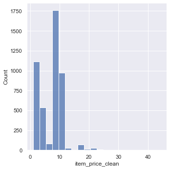

```
item_price_clean:
	 mean: 7.464335785374297
	 standard deviation: 4.245557197940302
	 median: 8.75
```

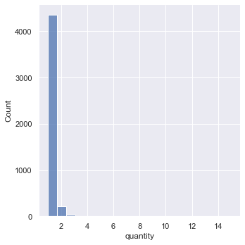

```
quantity:
	 mean: 1.0757247944612722
	 standard deviation: 0.41018633425753315
	 median: 1.0
```

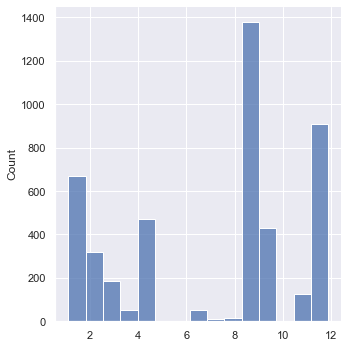

```
normalized price:
	 mean: 7.084424491562094
	 standard deviation: 3.665487441849343
	 median: 8.75
```

```python
import seaborn as sns
from matplotlib import pyplot as plt

sns.displot(df, x='item_price_clean', bins=20)
plt.show()
print("item_price_clean: \n\t mean: {}\n\t standard deviation: {} \n\t median: {}".format(df['item_price_clean'].mean(), df['item_price_clean'].std(), df['item_price_clean'].median()))
sns.displot(df, x='quantity', bins=20)
plt.show()
print("quantity: \n\t mean: {}\n\t standard deviation: {} \n\t median: {}".format(df['quantity'].mean(), df['quantity'].std(), df['quantity'].median()))
norm_price = df['item_price_clean']/df['quantity']
sns.displot(norm_price)
plt.show()
print("normalized price: \n\t mean: {}\n\t standard deviation: {} \n\t median: {}".format(norm_price.mean(), norm_price.std(), norm_price.median()))
```

Investigating the results from these attributes tells us quite a bit about our data:

- Firstly, most people order only one copy of the exact same item
- The most common price of singular items is in between 8 and 9 dollars
- But also very cheap singular items, as well as singular items above 11 dollars are often purchased. This is probably due to large meals (or combo deals) as well as very cheap sides like chips being quite popular.

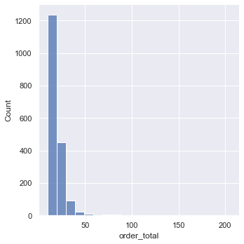

```
order_total:
	 mean: 18.811428571428568
	 standard deviation: 11.652511696471787
	 median: 16.2
```

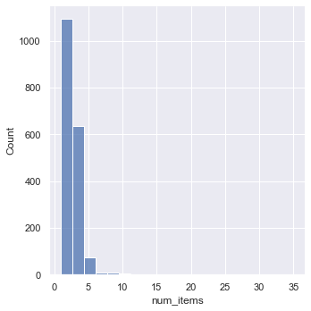

```
num_items:
	 mean: 2.711014176663032
	 standard deviation: 1.6776242381295468
	 median: 2.0
```

```python
df_agg = df[["order_id", "quantity", "item_price_clean"]].groupby("order_id").sum().rename(columns={'quantity': 'num_items', 'item_price_clean': 'order_total'})

sns.displot(df_agg, x='order_total', bins=20)
plt.show()
print("order_total: \n\t mean: {}\n\t standard deviation: {} \n\t median: {}".format(df_agg['order_total'].mean(), df_agg['order_total'].std(), df_agg['order_total'].median()))
sns.displot(df_agg, x='num_items', bins=20)
plt.show()
print("num_items: \n\t mean: {}\n\t standard deviation: {} \n\t median: {}".format(df_agg['num_items'].mean(), df_agg['num_items'].std(), df_agg['num_items'].median()))
```

This tells us some more interesting data:

- people very rarely order more than 6 items, however there are some instances of people having insanely large orders
- this also results in orders usually totalling less than 35 dollars (usually around 15 dollars), but due to singular large and expensive orders, the mean is almost around 19 dollars

## Correlation Analysis

For this task we aim to find some valuable correlations between dimensiosn within the chosen dataset. Interesting finds oculd be:

- Which items are more likely to be ordered together
- Which choices are paired together
- What kind of meat/souce is mostly chosen for a specific item menu

```python
import numpy as np
import seaborn as sns
from collections import defaultdict
```

```python
df2 = df.copy()
df2 = df2.drop(['item_name','choice_description','item_price'],axis=1)
choiceCols = [col for col in df.columns if 'choice' in col]
name_ids = defaultdict(lambda: len(name_ids))
df2['item_name_clean'] = [name_ids[ele] for ele in df2['item_name_clean']]
class_ids = defaultdict(lambda: len(class_ids))
df2['item_class'] = [class_ids[ele] for ele in df2['item_class']]
meat_ids = defaultdict(lambda: len(meat_ids))
df2['meat_option'] = [meat_ids[ele] for ele in df2['meat_option']]
df2
```

|  | order_id | quantity | item_price_clean | order_total | item_name_clean | item_class | meat_option | choice_AdoboMarinatedandGrilledChicken | choice_AdoboMarinatedandGrilledSteak | choice_Apple | ... | choice_SourCream | choice_Sprite | choice_TomatilloGreenChili(Medium) | choice_TomatilloGreenChiliSalsa | choice_TomatilloGreenChiliSalsa(Medium) | choice_TomatilloRedChili(Hot) | choice_TomatilloRedChiliSalsa | choice_TomatilloRedChiliSalsa(Hot) | choice_VegetarianBlackBeans | choice_WhiteRice |
| --- | --- | --- | --- | --- | --- | --- | --- | --- | --- | --- | --- | --- | --- | --- | --- | --- | --- | --- | --- | --- | --- |
| 0 | 1 | 1 | 2.39 | 11.56 | 0 | 0 | 0 | 0 | 0 | 0 | ... | 0 | 0 | 0 | 0 | 0 | 0 | 0 | 0 | 0 | 0 |
| 1 | 1 | 1 | 3.39 | 11.56 | 1 | 1 | 0 | 0 | 0 | 0 | ... | 0 | 0 | 0 | 0 | 0 | 0 | 0 | 0 | 0 | 0 |
| 2 | 1 | 1 | 3.39 | 11.56 | 2 | 1 | 0 | 0 | 0 | 1 | ... | 0 | 0 | 0 | 0 | 0 | 0 | 0 | 0 | 0 | 0 |
| 3 | 1 | 1 | 2.39 | 11.56 | 3 | 0 | 0 | 0 | 0 | 0 | ... | 0 | 0 | 0 | 0 | 0 | 0 | 0 | 0 | 0 | 0 |
| 4 | 2 | 2 | 16.98 | 16.98 | 4 | 2 | 1 | 0 | 0 | 0 | ... | 1 | 0 | 0 | 0 | 0 | 0 | 0 | 1 | 0 | 0 |
| ... | ... | ... | ... | ... | ... | ... | ... | ... | ... | ... | ... | ... | ... | ... | ... | ... | ... | ... | ... | ... | ... |
| 4617 | 1833 | 1 | 11.75 | 23.50 | 6 | 3 | 2 | 0 | 0 | 0 | ... | 1 | 0 | 0 | 0 | 0 | 0 | 0 | 0 | 0 | 0 |
| 4618 | 1833 | 1 | 11.75 | 23.50 | 6 | 3 | 2 | 0 | 0 | 0 | ... | 1 | 0 | 0 | 0 | 0 | 0 | 0 | 0 | 0 | 0 |
| 4619 | 1834 | 1 | 11.25 | 28.75 | 19 | 7 | 1 | 0 | 0 | 0 | ... | 0 | 0 | 0 | 0 | 0 | 0 | 0 | 0 | 0 | 0 |
| 4620 | 1834 | 1 | 8.75 | 28.75 | 19 | 7 | 1 | 0 | 0 | 0 | ... | 0 | 0 | 0 | 0 | 0 | 0 | 0 | 0 | 0 | 0 |
| 4621 | 1834 | 1 | 8.75 | 28.75 | 19 | 7 | 1 | 0 | 0 | 0 | ... | 0 | 0 | 0 | 0 | 0 | 0 | 0 | 0 | 0 | 0 |

4622 rows × 54 columns

At first, we delete dimensions that will not be of use for the classification task. These dimensions are the cleaning leftovers, namely "item_name", "choice_description" and "item_price".  
Furthermore, we create keys for the cleaned item names, classes and meat options. After these steps we have a solely numerical dataframe to work with.

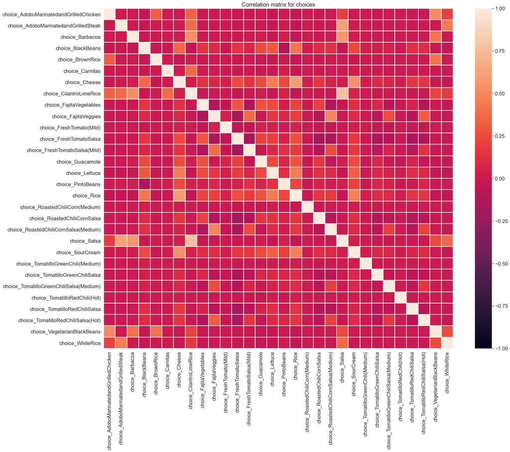

```python
dfChoices = df2[df2.item_class != (class_ids.get('Chips') or class_ids.get('Drink'))]
dropArr = []
for col in dfChoices.columns:
    if dfChoices[col].sum() == 0:
        dropArr.append(col)
dfChoices = dfChoices.drop(dropArr,axis = 1)
dfChoices = dfChoices.drop(['order_id','choice_NaN','quantity','order_total','item_price_clean','meat_option','item_class','item_name_clean'], axis = 1)
sns.set(font_scale = 1.5)
plt.subplots(figsize=(25,20))
ax = plt.axes();
dfChoices_corr = dfChoices.corr()
sns.heatmap(dfChoices_corr,  linewidths = 1, fmt='d',vmin = -1, vmax=1)
ax.set_title('Correlation matrix for choices')
```

```python
def printMinMaxCorrs(df,n):
    maxDf = pd.DataFrame()
    minDf = pd.DataFrame()
    for col in df:
       maxDf[col] =  sorted(df[col], reverse = True)[:2]
       minDf[col] =  sorted(df[col])[:1]
    maxDf = maxDf.T.sort_values(by = 1, ascending = False)[1].head(n)
    minDf = minDf.T.sort_values(by = 0, ascending = True)[0].head(n)
    for index in maxDf.index:
        print(index + " + " + df[index].loc[df[index] >= maxDf[index]].sort_values(ascending = True).index[0] + " (" + str(maxDf[index]) + ")" )
    print("===========================")
    for index in minDf.index:
        print(index + " + " + df[index].loc[df[index] <= minDf[index]].sort_values(ascending = False).index[0] + " (" + str(minDf[index]) + ")" )
    return

printMinMaxCorrs(dfChoices_corr,8)
```

```
choice_Salsa + choice_CilantroLimeRice (0.7711454116455818)
choice_CilantroLimeRice + choice_Salsa (0.7711454116455818)
choice_AdoboMarinatedandGrilledSteak + choice_Salsa (0.6119072445509834)
choice_Cheese + choice_Rice (0.5943938931156326)
choice_Rice + choice_Cheese (0.5943938931156326)
choice_Barbacoa + choice_Salsa (0.5770580139093507)
choice_SourCream + choice_Cheese (0.5527141297538288)
choice_AdoboMarinatedandGrilledChicken + choice_VegetarianBlackBeans (0.5159402283755015)
===========================
choice_RoastedChiliCornSalsa + choice_FreshTomatoSalsa (-0.21680980810595052)
choice_FreshTomatoSalsa + choice_RoastedChiliCornSalsa (-0.21680980810595052)
choice_FreshTomatoSalsa(Mild) + choice_FreshTomatoSalsa (-0.18719319994933628)
choice_TomatilloRedChiliSalsa + choice_FreshTomatoSalsa (-0.17948032098562425)
choice_FajitaVeggies + choice_FreshTomatoSalsa (-0.17246728560132762)
choice_RoastedChiliCornSalsa(Medium) + choice_FreshTomatoSalsa (-0.16236436280312605)
choice_TomatilloRedChiliSalsa(Hot) + choice_FreshTomatoSalsa (-0.15878566852011303)
choice_TomatilloGreenChiliSalsa + choice_FreshTomatoSalsa (-0.14904853888594566)
```

### Correlation between choice items

- Salsa + Cilantro Lime Rice (0.771145)
- Salsa + Adobo Marinated and Grilled Steak (0.611907)
- Rice + Cheese (0.594384)
- Adobo Marinated and Grilled Chicken + vegetarian Black Beans (0.515940)

For these items we can assume that they are chosen together because customers tend to like these combinatiosn the most.  
When we look at the uncommon itemsets we see, that there are hardly any strong negative correlations between items. However, most items paired with any other item that is rather similar (2 kinds of souces for example) yields slightly negative correlation,  
since most people will most likely not order multiple salsas or souces with their meals.  
Most negative correlating items:

- Roasted Chilli Corn Salsa and Fresh Tomato Salsa (-0.216810)
- Mild Fresh Tomato Salsa and Normal Fresh Tomato Salsa (-0.187193)
- Normal Fresh Tomato Salsa and Fajita Veggies (-0.172467)
- Pinto Beans and Black beans (-0.137946)

```
Meat_No meat + Class_Chips (0.7045592947966681)
Class_Chips + Meat_No meat (0.7045592947966681)
Meat_Chicken + Class_ChickenBowl (0.6047823806999141)
Class_ChickenBowl + Meat_Chicken (0.6047823806999141)
Class_Drink + Meat_No meat (0.5231807072007075)
item_price_clean + Meat_Chicken (0.4488319796358063)
Class_Burrito + item_price_clean (0.36911318699567847)
Meat_Steak + item_price_clean (0.30449873473168)
Class_BurritoBowl + Meat_Steak (0.3010887858547429)
Meat_Veggie + Class_BurritoBowl (0.2316022858728448)
===========================
item_price_clean + Meat_No meat (-0.8273906256516007)
Meat_No meat + item_price_clean (-0.8273906256516007)
Meat_Chicken + Meat_No meat (-0.5607611066795927)
Class_Drink + item_price_clean (-0.5195534446339565)
Class_Chips + item_price_clean (-0.5191539286169856)
Class_Burrito + Meat_No meat (-0.4517596411605319)
Class_ChickenBowl + Meat_No meat (-0.33913843710160135)
Meat_Steak + Meat_No meat (-0.3324632918802703)
Class_BurritoBowl + Meat_No meat (-0.24920263522814814)
Class_SoftTaco + Meat_No meat (-0.18466679248648515)
```

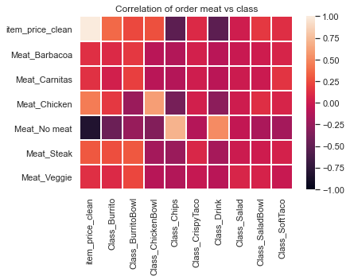

```python
sns.set(font_scale = 1)
df_corr = df.drop(choiceCols,axis = 1)
meat = pd.get_dummies(df.meat_option, prefix='Meat')
classes = pd.get_dummies(df.item_class, prefix='Class')
df3 = pd.concat([df['item_price_clean'], meat], axis = 1)
df3 = pd.concat([df3, classes], axis = 1)
df_MC = df3.corr()
meatCols = [col for col in df_MC.columns if 'Meat' in col]
classCols = [col for col in df_MC.columns if 'Class' in col]
df_MC_corr = df_MC.drop(meatCols, axis= 1)
df_MC_corr = df_MC_corr.drop(classCols, axis= 0)
ax = plt.axes()
sns.heatmap(df_MC_corr,  linewidths = 1, fmt='d', ax= ax, vmin = -1, vmax=1)
ax.set_title('Correlation of order meat vs class')
plt.plot()
printMinMaxCorrs(df_MC,10)
```

### Meat vs Class of item

For the next correlation matrix we one-hot encoded the meat and class dimensions and then checked if any correlations between dimensions exist.  
With the help of the above heatmap we can quickly see, which classes are mostly served with which meat.  
We also included the price of the product groups in order to get a comparison what may be cheaper than other groups.  
Positively correlating itemsets:

- No Meat + Chips (0.70456)
- Chicken Meat + Chicken Bowl (0.604782)
- Drink + No Meat (0.5232)
- Chicken Meat + Item Price (0.44883)

These are a couple of important correlations we could find in our data. First of all, having drinks and chips correlating positively with the "no meat" option is no surprise.  
The same applies to the correlations of chicken meat and chicken bowl. So, there are not a lot of unsurprising correlations in the positively correlating dimensions.

Negatively correlating dimensions:

- Item Price + No Meat (-0.82739)
- Chicken Meat + No Meat (-0.56076)
- Chips + Item Price (-0.51915)
- Burito + No Meat (-0.451759)

The negatively correlating dimensions also yield some foreseeable results like the correlation between the dimensions chicken meat and no meat. Also, no meat correlates negatively with the item price. This however comes from the fact, that the two cheapest categories, namely drink and chips, are both no meat categories. (Which also shows in the positively correlating dimensions)  
We can also observe, that all burritos and bowls have a slightly negative correlation with the no_meat option. Furthermore, chicken also has a slightly negative correlation to burrito bowls. However, single Burritos do not follow this trend, meaning burritos are more likely to be ordered with chicken than burrito bowls are. Burritos and bowls in general are also likely to contain meat.

```
quantity + item_price_clean (0.8318586460072502)
item_price_clean + quantity (0.8318586460072502)
class_Burrito + item_price_clean (0.4243051914381689)
class_ChickenBowl + item_price_clean (0.37032561677016157)
class_BurritoBowl + item_price_clean (0.35368616939482)
class_Drink + quantity (0.3346959236873426)
class_Chips + quantity (0.2842302284042739)
class_SaladBowl + item_price_clean (0.22419169854586662)
class_SoftTaco + item_price_clean (0.1986730624278173)
class_CrispyTaco + item_price_clean (0.1591568403752889)
===========================
class_Burrito + class_ChickenBowl (-0.18066866295687753)
class_ChickenBowl + class_Burrito (-0.18066866295687753)
class_Chips + class_Burrito (-0.1406533818493908)
class_BurritoBowl + class_Burrito (-0.1362642439906255)
class_SoftTaco + class_ChickenBowl (-0.12238101391607958)
class_SaladBowl + class_Chips (-0.09118782307433172)
class_Drink + class_Burrito (-0.08294705361315341)
class_CrispyTaco + class_SaladBowl (-0.05089265154485286)
class_Salad + class_ChickenBowl (-0.04232099686635476)
item_price_clean + class_Drink (-0.019095421721662783)
```

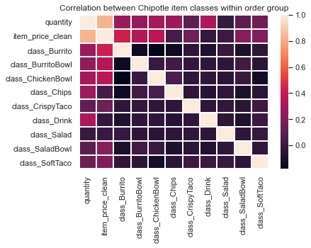

```python
sns.set(font_scale = 1.5)
dfGrouped = df.copy()
dfGrouped = dfGrouped[['order_id','quantity','item_price_clean']]
classes = pd.get_dummies(df.item_class, prefix='class')
dfGrouped = pd.concat([dfGrouped, classes], axis = 1)
dfGrouped = dfGrouped.groupby(['order_id']).sum()
dfGrouped_corr = dfGrouped.corr()

sns.set(font_scale = 1)
ax = plt.axes()
sns.heatmap(dfGrouped_corr,  linewidths = 1, fmt='d', ax= ax)
ax.set_title('Correlation between Chipotle item classes within order group')
plt.plot()
printMinMaxCorrs(dfGrouped_corr,10)
```

For the last correlation analysis we grouped the orders by order id. With this, we wanted to check if any items are ordered together. In addition to the item classes we also added the quantity dimension to see, if there are items which are ordered more proportionally than others. However, besides some correlations between an increase of cost with an increase of quantity (which should not be shocking), there is not much of interest in this analysis. Meaning, customers do not order particular items together, it seems more random. There is only some slight negative correlations between ordering burritos and any kind of bowls. Besides this, we can also observe, that burritos, burrito bowls and chicken bowls are leading to the highest price increase.

## Clustering

Clustering is part of **unsupervised learning** and its goal is to find groups of similar objects and possibly discover interesting patterns. Since clustering is mostly based on visual insights, we need to **downproject** our data into lower dimensional space (2D).

Opposed to supervised learning in clustering it is often not clear beforehand, what do we want to discover. Mostly we cluster the data, analyze if there are interesting patterns and only then try to interpret the results. Since this also holds for our dataset and we don't even know from the beginning, which parts of the dataset we want to use for clustering and visual inspection our goal is to provide a **generic and flexible overview** that provides the following configuration possibilities:

- Select the columns that should be used for clustering. In particular the user should be able to select between the columns **quantity, item_price_clean, order_total** and the **side-dish choices**.
- Select two different types of clustering algorithms: here we choose **KMEANS** and **DBSCAN**.
- Choose most important parameters of the clustering algorithms.
- Select particular clusters that seem to be interesting.
- Analyse the distribution of the selected samples in relation to the generated categorical columns **item_class** and **meat_option**. In addition to that we want to see the average price of the items that are selected.

This structure allows also to investigate a relationship that seems interesting and promising:

- If we downproject and cluster the side-dishes, can we find clusters corresponding to the self-generated categorical attributes **item_class** and **meat_option**? Can we find clusters that correspond to the price?

```python
# first we want to convert parts of the dataframe into numpy matrices
# this will be the data that can be clustered
filter_col = [col for col in df if col.startswith('choice') and col != "choice_description"]
choice_list = df[filter_col].values
item_price = df['item_price_clean'].values
order_total = df['order_total'].values
quantity = df['quantity'].values

# we also need to setup the color palette ...
import seaborn as sns
colors = sns.color_palette(n_colors=10)

# ... and import plotting tools
from matplotlib import pyplot as plt
import matplotlib.patches as mpatches
```

We will use a dictionary **current_context** to store parts of the data and the selection.

```python
# we do not want to pass everything via parameters, so we define a context
current_context = {}

def reset_context():
    global current_context
    current_context = {
        'data': {'choices': choice_list, 'item_price': item_price, 'order_total': order_total, 'quantity': quantity},
        'pca_data': None,  # must be of shape (4622, 2) -> 2 dimensions
        'selected_data_rows': np.full(shape=(len(choice_list),), fill_value=False), # indices of selected datapoints
        'bar_target': {'item_class': df['item_class'], 'meat_option': df['meat_option']},
        'price_stats': {'item_price_clean': df['item_price_clean']}, # used to calculate average price
        'clusters':{}, # maps class labels to corresponding indices
        'display_data': df[['quantity', 'choice_description', 'item_price']]
    }

def set_pca_data(data):
    global current_context
    current_context['pca_data'] = data

def set_cluster(label, indices):
    global current_context
    current_context['clusters'][label] = indices

reset_context()
```

To be able to visually inspect high-dimensional data we need to downproject to 2D space. One possibility to do this is by applying **Principal Component Analysis (PCA)**. Reducing dimensions comes with loss of information, of course, but PCA tries to preserve as much information as possible. To quantify this loss of information, we look at an important measure: the **explained variance ratio**. This tells us how much of the original information (variance) is preserved by the two principal components we use for plotting.

```python
# downprojection via pca
from sklearn import decomposition

def run_pca(data):
    pca = decomposition.PCA(n_components=2, random_state=99)
    transformed_data = pca.fit(data).transform(data)
    print("Explained variance by PC 1 and PC 2: ", pca.explained_variance_ratio_)
    return transformed_data
```

The first clustering algorithm is **K-means**. With **K-means** the number of clusters must be specified beforehand. The algorithm then tries **minimize the within-cluster-sum-of-squares**, also called **inerta**, in an expectation-maximization process. The final **intertia** will be printed to be able to quantify the performance of the algorithm.

```python
# first cluster algorithm: KMEANS
from sklearn.cluster import KMeans

# one parameter: the number of clusters
def run_kmeans(n_clusters):
    data = current_context['pca_data']
    instance = KMeans(n_clusters=n_clusters, random_state = 99)
    clusters_assignment = instance.fit_predict(data)
    unique_labels = np.unique(clusters_assignment)
    # store the cluster membership mask in context variable
    for label in unique_labels:
        set_cluster(str(label) + ". cluster", clusters_assignment == label)
    plt.scatter(data[:, 0], data[:, 1], s=20, c=[colors[label] for label in clusters_assignment])
    patches = [mpatches.Patch(color=colors[label], label=str(label) + ". cluster") for label in unique_labels]
    # place legend to the right side of the plot
    plt.legend(handles=patches, bbox_to_anchor=(1.05, 1), loc='upper left')
    plt.title('KMEANS: number of clusters: %d' % n_clusters)
    plt.show()
    print("K-Means within-cluster-sum-of-squares: %.2f\n" % instance.inertia_)
    # is defined in one of the next cells - necessary for interactively choosing the clusters
    update_cluster_list(unique_labels)
```

As a second cluster algorithm we choose **DBSCAN**, since this algorithm works very different from K-means and usually also leads to very different clusters. DBSCAN is **density-based**, which means it clusters areas with high density. Instead of specifying a fixed number of cluster beforehand, DBSCAN takes the arguments *eps (a distance)* and *min_samples (integer number)*. Then it tries to find **core samples** that have at least *min_samples* within a radius of *eps*. Multiple core samples within a radius of eps form a cluster. A sample without a core point in its *eps-radius* is an **outlier** and labelled as **-1**. The parameter **min_samples** primarily controls how tolerant the algorithm is to noise, while *eps* must be chosen appropriately according to the distances in a particular dataset.

```python
# second cluster algorithm: DBSCAN
from sklearn.cluster import DBSCAN

# adapted from:
# https://scikit-learn.org/stable/auto_examples/cluster/plot_dbscan.html#sphx-glr-auto-examples-cluster-plot-dbscan-py
# two parameters:
# eps ... maximum distance for two samples to be considered as neighbors
# min_samples ... amount of neighbouring samples needed for a sample to considered a core point
def run_dbscan(eps, min_samples):
    data = current_context['pca_data']
    db = DBSCAN(eps=eps, min_samples=min_samples).fit(data)
    labels = db.labels_
    unique_labels = set(labels)
    n_clusters_ = len(unique_labels) - (1 if -1 in labels else 0)
    n_noise_ = list(labels).count(-1) # samples with label -1 are considered noise points
    core_samples_mask = np.zeros_like(labels, dtype=bool)
    core_samples_mask[db.core_sample_indices_] = True # mask for core points
    marker = 'o'
    for i, (k, col) in enumerate(zip(unique_labels, colors)):
        if k == -1:
            # Black used for noise.
            col = [0, 0, 0, 1]

        class_member_mask = (labels == k)
        # store class member mask in current context variable
        set_cluster(str(k) + ". cluster", class_member_mask)

        # plot and define layout of core points and non-core points
        xy = data[class_member_mask & core_samples_mask]
        plt.plot(xy[:, 0], xy[:, 1], marker, markerfacecolor=tuple(col), markeredgecolor='k', markersize=6)

        xy = data[class_member_mask & ~core_samples_mask]
        plt.plot(xy[:, 0], xy[:, 1], marker, markerfacecolor=tuple(col), markeredgecolor='k', markersize=3)

    # this is a bit tricky, since we don't know the number of clusters beforehand
    # not a nice solution, but it does not makes sense to display a huge number of clusters
    if len(unique_labels) > len(colors):
        unique_labels = list(unique_labels)[:len(colors)]
    patches = [mpatches.Patch(color=colors[i], label=str(label) + ". cluster") for i, label in enumerate(unique_labels)]
    # place legend to the right side of the plot
    plt.legend(handles=patches, bbox_to_anchor=(1.05, 1), loc='upper left')
    plt.title('DBCSAN: estimated number of clusters: %d' % n_clusters_)
    plt.show()
    print("Number of noise points detected: %d\n" % np.sum(labels == -1))
    # is defined in one of the next cells - necessary for interactively choosing the clusters
    update_cluster_list(unique_labels)
```

The two procedures in the following cell control interactive elements:

- *update_cluster_list(labels)*: allows to select the clusters that should be analyzed in detail and further allows to select the target attribute for the barplot
- *on_cluster_selection_change(cluster_selection, target_selection)*: uses all the selections to display the final barplot and the average item price within the selected samples

```python
from ipywidgets import widgets, interact
from tabulate import tabulate

# after running clustering, we want to select clusters for detail analysis
def update_cluster_list(labels):
    print("Select the clusters you want to analyse in detail (multi selection by holding Ctrl): ")
    # cluster selection widget
    multi_select = widgets.SelectMultiple(options=[str(label) + ". cluster" for label in labels], description="Selection")
    # selection of categorical attribute for histogram
    bar_target = widgets.RadioButtons(options=list(current_context['bar_target'].keys()),
                                       description="Barplot Target")
    interact(on_cluster_selection_change, cluster_selection=multi_select, target_selection=bar_target)

# present results of detailed cluster analysis
def on_cluster_selection_change(cluster_selection, target_selection):
    selected_clusters = cluster_selection
    all_clusters = current_context['clusters']
    data_selection = current_context['selected_data_rows']
    # collect samples of all selected clusters in a mask
    for cluster in selected_clusters:
         data_selection = np.logical_or(data_selection, all_clusters[cluster])

    nr_dp = np.sum(data_selection)
    print("Number of selected data points: ", nr_dp)
    if nr_dp > 0:
        current_context['bar_target'][target_selection][data_selection].value_counts().plot(kind='bar')
        print("Average price of items in cluster: %.2f" %
              current_context['price_stats']['item_price_clean'][data_selection].mean())
```

The *init_app(data_selection, algo_selection)* procedure finally runs the app by using all the procedures we defined so far. The process starts by questioning the user to choose the data and the algorithm that should be applied. Then it performs **standardization** followed by **PCA** and the actual **clustering algorithm**. The results and all interactive elements except the data and algorithm selection are created by the helper procedures defined above.

```python
from sklearn.preprocessing import StandardScaler

print("Start by selecting data (multi selection by holding Ctrl) and the algorithm:")
# starts the visualization and clustering application by letting the user choose the dataset columns and the algorithm
@interact(
    data_selection=widgets.SelectMultiple(options=list(current_context['data'].keys()), description="Data:"),
    algo_selection=widgets.RadioButtons(options=['KMEANS', 'DBSCAN'], description="Algo:")
)
def init_app(data_selection, algo_selection):
    reset_context() # reset context variable
    if len(data_selection) > 0:
        # first collect chosen columns in a data matrix
        data_mat = np.column_stack(tuple([current_context['data'][data_col] for data_col in data_selection])) \
                        .astype(np.float64)
        # we need at least 2 dimensions for pca
        if data_mat.shape[1] > 1:
            # only standardize if 'choices' columns not in selection ->
            # this would give extremely low explained variance by pca
            if 'choices' not in data_selection:
                # scale data (makes finding appropriate parameters easier, important for DBSCAN)
                data_mat = StandardScaler().fit_transform(data_mat)
            # then perform pca
            set_pca_data(run_pca(data_mat)) # assign to current context
            # now perform clustering with the resulting 2D data
            if algo_selection == 'DBSCAN':
                interact(run_dbscan, eps=(0.01,1.0), min_samples=(1, 40))
            elif algo_selection == 'KMEANS':
                interact(run_kmeans, n_clusters=(1,len(colors)))
        else:
            print("Selected data must contain at least 2 feature columns")
```

```
Start by selecting data (multi selection by holding Ctrl) and the algorithm:
```

### Interpretation and Findings

It is very interesting to play around and see the differences between **K-means** and **DBSCAN**, also to get a notion of what density-based really means. While DBSCAN tends to detect one big cluster and lots of small island clusters mostly, K-means visually creates boundaries based on the position of the centroids.

Note: to keep the legend and diagram clear a maximum of 10 clusters (most prominant ones) is displayed

We will **interpret two insteresting settings in detail** in the following:

#### First Example: DBSCAN

[figure not shown]

- **Data: 'choices', Algo: 'DBSCAN', eps: 0.1, min_samples: 25**: DBSCAN really needs very exact fine-tuning of parameters to get visually promising clusters with the selected data. **Core points** are visualized with a larger marker size than **non-core points**. Our two PCs explain around 45% of the total variance when reducing from 47 to 2 dimensions. Furthermore, in this setting 532/4622 points are **noise points**, which is quite a lot.
  - **cluster: 0**: leftmost cluster, contains 1246 data points containing over 1000 "Chips" items, points lie exactly on top of each other -> makes perfectly sense, since "Chips" do not come with side dishes (only zero vectors); additionally average item price in this cluster is with an average price of 3.27\$ very cheap (e.g. Chips are much cheaper than a Burrito)
  - **cluster: 1**: right of cluster 1, contains 538 smaples, nearly all of them are "Drinks", type of Drink is listed as side-dish, again very cheap: 2,60
  - **cluster 4**: 389 data points, more than half of them are "Burritos", therefore items in this cluster are expensive (9.52\$), side-dishes ordered with Burritos appear to have some similarities (salsa, rice, beans, ... are common)
  - **cluster 5 and 6**: 27 and 35 samples, are dominated by ChickenBowl, BurritoBowl, Burrito -> "meat" clusters (mostly chicken), most expensive ones with 12,43 and 12,86 Dollar on average
  - **further details**: the map seems to have an implicit sorting of the prices from left to right (without prices included in the clustering!), "Drinks" and "Chips" only appear in the clusters 0 and 1, other clusters are mostly dominated by "Burrito" (majority classes - 1150)

#### Second Example: KMEANS

[figure not shown]

The second example aims at finding clusters with uncommon distributions containing meat options. We will use **K-means with n_cluster=6**, since there are 6 meat option classes. Therefore it is important to know the distribution of all samples concerning meat_option:

[figure not shown]

- **Data: 'choices', 'item_price', 'quantity', Algo: 'KEMANS', n_clusers: 6**: This time our two principal components (resulting from 49 downprojected dimensions) can explain more of the total variance than before (> 90%). All of the 4622 samples are displayed, since K-means does not filter out noise points.
  - **clusters 1 and 5**: contain together 1719 data points, which is a large portion of the total data set; interestingly this two clusters consist of only "no_meat" samples, if we look at the item_class distribution the clusters only contain "Drinks" and "Chips" (similar to what DBSCAN identified), cluster 1 has an average price of 1.89\$, which ist extremely cheap (cluster 5 with 4.49\$ also cheap)
  - **cluster 3**: "outlier" cluster, contains very expensive items (average: 31.38 Dollar, e.g. Steak is a bit more prominent than in other clusters),
  - **cluster 4**: even more dominated by Chicken and Steak than other classes, very expensive (19.05\$)

In this example the clusters become more expensive, the further on the right side of the plot they are located. This has the following (problematic) reason: The 'choice_description' column is one-hot encoded and therefore has 47 dimensions now. If we use those 47 columns, 'quantity' and 'item_price' and standardize the data, then the two principal components can only explain around 10\% of the total variance, which makes the clustering almost useless. Therefore we decided not to standardize the data if the 'choice' columns are included. This has the effect that the columns' magnitudes influence PCA. It is a logical consequence that the first PC (first axis) then picks up almost all of the signal of the 'item_price' column (highest magnitude).

### How the clustering task is fulfilled:

1) Reducing the number of dimension using an appropriate technique (PCA)

2) Cluster algorithm and parameters can be interactively selected

3) One or more clusters can be selected

4) Selected data can be used in a second interactive visualization according to an overview+detail setup (barplot with radio buttons)

5) As a final step some findings have been interpreted